# DATA607_10th_ASSGNMNT_V00

KoohPy <- Koohyar Pooladvand

2024-03-31

## Week 10th Assignment intro

In this week’s assignment we will be working with sentiment analyses.

first, we will start by reading Text Mining with R, [Chapter 2 looks at Sentiment Analysis](https://www.tidytextmining.com/sentiment.html). The goal of this assignment is to start by getting the primary example code from chapter 2 and replicate it in R-Markdown.

Then we extend the code in two ways:

1. Work with a different corpus of your choosing,
2. and Incorporate at least one additional sentiment lexicon (possibly from another R package that you’ve found through research).

At the end, an.Rmd file will be posted in your GitHub repository and to rpubs.com. ## Code Initiation

Here I load the required libraries and ensure all the required packages are installed before running the following blocks of codes.

```
## [1] "All required packages are installed"
```

## Chapter Two Code replication

In this section, we replicate the codes in chapter 2 of the above-mentioned book. I have chosen Mark Twain’s books and used Project Gutenberg to download his books. I have chosen his books that have only one title and among them, I have chosen his books that were stories.

I have also entertained the idea of downloading of his famous and best books, but I had difficulty downloading all from Gutenburg and stopped after some time.

```
In our analysis, we followed the sentiment analysis approach outlined in the textbook (Silge & Robinson, 2017).
```

```r
get_sentiments("afinn")
```

```
## # A tibble: 2,477 × 2
##    word       value
##    <chr>      <dbl>
##  1 abandon       -2
##  2 abandoned     -2
##  3 abandons      -2
##  4 abducted      -2
##  5 abduction     -2
##  6 abductions    -2
##  7 abhor         -3
##  8 abhorred      -3
##  9 abhorrent     -3
## 10 abhors        -3
## # ℹ 2,467 more rows
```

```r
get_sentiments("bing")
```

```
## # A tibble: 6,786 × 2
##    word        sentiment
##    <chr>       <chr>
##  1 2-faces     negative
##  2 abnormal    negative
##  3 abolish     negative
##  4 abominable  negative
##  5 abominably  negative
##  6 abominate   negative
##  7 abomination negative
##  8 abort       negative
##  9 aborted     negative
## 10 aborts      negative
## # ℹ 6,776 more rows
```

```r
get_sentiments("nrc")
```

```
## # A tibble: 13,872 × 2
##    word        sentiment
##    <chr>       <chr>
##  1 abacus      trust
##  2 abandon     fear
##  3 abandon     negative
##  4 abandon     sadness
##  5 abandoned   anger
##  6 abandoned   fear
##  7 abandoned   negative
##  8 abandoned   sadness
##  9 abandonment anger
## 10 abandonment fear
## # ℹ 13,862 more rows
```

```r
library(janeaustenr)


# Load Mark Twain books from Project Gutenberg
mark_twain_books <- gutenberg_works(author == "Twain, Mark")

# Make a new column named book and only keep the titles without ", Chapter", ", Part", or "-"
mark_twain_books <- mark_twain_books %>%
  mutate(book = gsub("[—:,].*", "", title))

# Select only the books that have one title
mark_twain_books_sel <- mark_twain_books %>%
  count(book) %>%
  filter(n == 1) %>%
  inner_join(mark_twain_books, by = "book")

# Choose 6 random samples of Mark Twain books to download, choosing from single title books
set.seed(2014)

MT_best_book_list <- c("The Innocents Abroad",
                       "Life on the Mississippi",
                       "A Connecticut Yankee in King Arthur's Court",
                       "The Prince and the Pauper",
                       "Adventures of Huckleberry Finn",
                       "The Adventures of Tom Sawyer")

mark_twain_books_sel_6 <- mark_twain_books %>%
  filter(grepl(paste(MT_best_book_list, collapse = "|"), title)) %>%
  select(book, title, everything())


MT_one_book_list <- c("A Horse's Tale",
                      "The Adventures of Huckleberry Finn \\(Tom Sawyer's Comrade\\)",
                      "The Man That Corrupted Hadleyburg",
                      "Tom Sawyer Abroad",
                      "Tom Sawyer, Detective",
                      "The American Claimant")

mark_twain_books_sel_6 <- mark_twain_books %>%
  filter(grepl(paste(MT_one_book_list, collapse = "|"), title)) %>%
  select(book, title, everything())


#mark_twain_books_sel_6 <- sample_n(mark_twain_books_sel, 6)


mark_t_books_downloaded <- list()
DF_book <- tibble(book = character(0), title = character(0), text = character(0))

# Run for each of the 6 selected books and download them
for (i in seq_along(mark_twain_books_sel_6$gutenberg_id)) {
  #get the ID and titl of the book
  book_id <- mark_twain_books_sel_6$gutenberg_id[i]
  book_title <- mark_twain_books_sel_6$title[i]
  #downlaod from gutenberg
  mark_t_books_downloaded[[i]] <- gutenberg_download(book_id)

  rep_size <- length(mark_t_books_downloaded[[i]]$text)
  # Combine all text paragraphs into a single text
  #book_text <- paste(mark_t_books_downloaded[[i]]$text, collapse = " ")

  DF_book <- rbind(DF_book, tibble(book = rep(book_id,rep_size), title = rep(book_title,rep_size), text = mark_t_books_downloaded[[i]]$text))
}
```

```
## Determining mirror for Project Gutenberg from https://www.gutenberg.org/robot/harvest
```

```
## Using mirror http://aleph.gutenberg.org
```

```r
tidy_MT_book <- DF_book %>%
  group_by(book) %>%
  mutate(
    linenumber = row_number(),
    chapter = cumsum(str_detect(text,
                                regex("^chapter [\\divxlc]",
                                      ignore_case = TRUE)))) %>%
  ungroup() %>%
  unnest_tokens(word, text)

#Get sentences
tidy_MT_book_sentence <- DF_book %>%
  group_by(book) %>%
  mutate(
    linenumber = row_number(),
    chapter = cumsum(str_detect(text,
                                regex("^chapter [\\divxlc]",
                                      ignore_case = TRUE)))) %>%
  ungroup() %>%
  unnest_tokens(sentence, text, token = "sentences")



#tidy_books <- austen_books() %>%
#  group_by(book) %>%
#  mutate(
#    linenumber = row_number(),
#    chapter = cumsum(str_detect(text,
#                                regex("^chapter [\\divxlc]",
#                                      ignore_case = TRUE)))) %>%
#  ungroup() %>%
#  unnest_tokens(word, text)


nrc_joy <- get_sentiments("nrc") %>%
  filter(sentiment == "joy")

# chose a random book
random_book <- sample(unique(tidy_MT_book$title),1)

tidy_MT_book %>%
  filter(title == random_book) %>%
  inner_join(nrc_joy) %>%
  count(word, sort = TRUE)
```

```
## # A tibble: 149 × 2
##    word          n
##    <chr>     <int>
##  1 good         45
##  2 child        28
##  3 mother       23
##  4 beautiful    16
##  5 music        12
##  6 glad          9
##  7 kind          9
##  8 love          8
##  9 pretty        8
## 10 salute        8
## # ℹ 139 more rows
```

```r
mark_twain_sentiment <- tidy_MT_book %>%
  inner_join(get_sentiments("bing")) %>%
  count(title, index = linenumber %/% 80, sentiment) %>%
  pivot_wider(names_from = sentiment, values_from = n, values_fill = 0) %>%
  mutate(sentiment = positive - negative)
mark_twain_sentiment_2 <- tidy_MT_book %>%
  group_by(title) %>%
  inner_join(get_sentiments("nrc") %>%
               filter(sentiment %in% c("positive","negative")))%>%
  mutate(method = "NRC")%>%
  count(method, index = linenumber %/% 80, sentiment) %>%
  pivot_wider(names_from = sentiment,
              values_from = n,
              values_fill = 0) %>%
  mutate(sentiment = positive - negative)
```

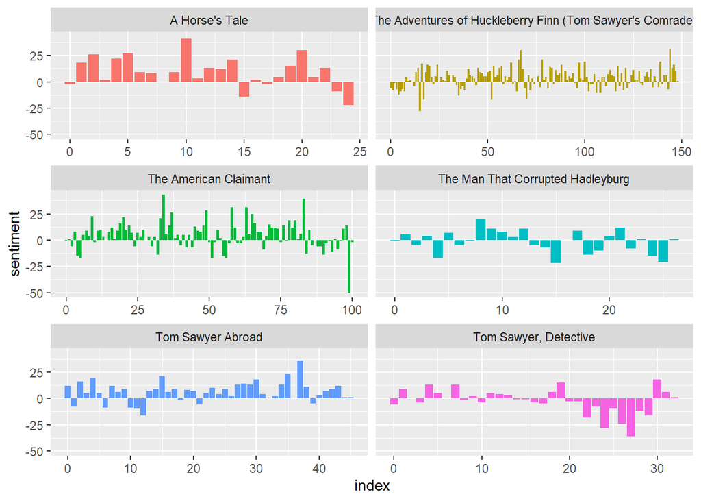

```r
ggplot(mark_twain_sentiment, aes(index, sentiment, fill = title)) +
  geom_col(show.legend = FALSE) +
  facet_wrap(~title, ncol = 2, scales = "free_x")
```

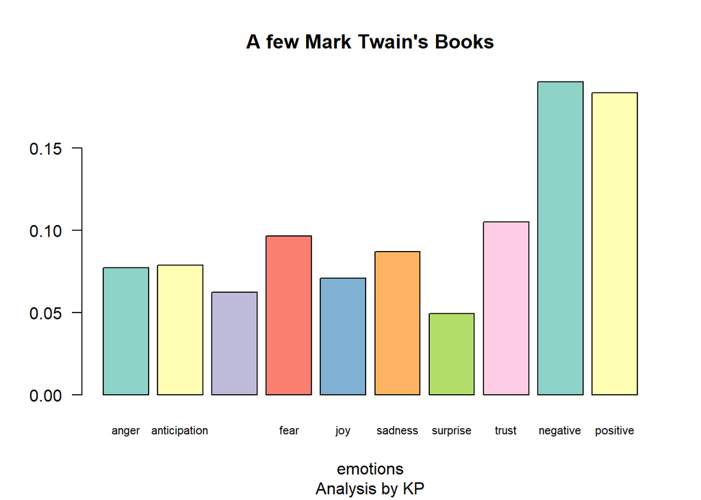

```r
#use nrc_get sentiment to evalate all books
MT_sentiment_scores <- tidy_MT_book %>%
  group_by(title) %>%
  summarize(words = toString(word)) %>%
  ungroup() %>%
  mutate(sentiment = get_nrc_sentiment(words, language = "english"))

# Flatten the nested data
flattened_data <- MT_sentiment_scores %>%
  unnest(cols = sentiment)


barplot(
  colSums(prop.table(flattened_data[, 3:12])),
  space = 0.2,
  horiz = FALSE,
  las = 1,
  cex.names = 0.7,
  col = brewer.pal(n = 8, name = "Set3"),
  main = "A few Mark Twain's Books",
  sub = "Analysis by KP",
  xlab="emotions", ylab = NULL)
```

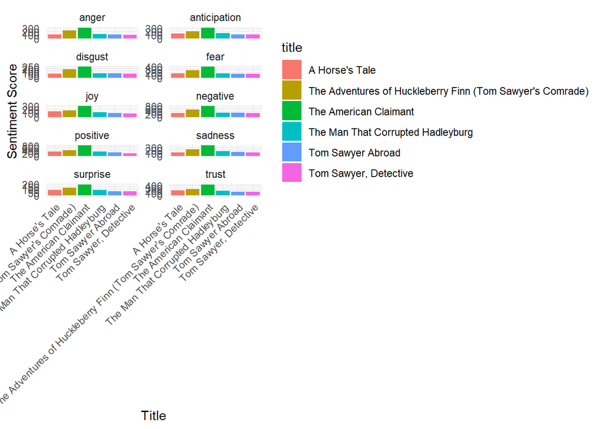

```r
# First, let's reshape the data into a long format
flattened_data_long <- flattened_data %>%
  pivot_longer(cols = 3:12, names_to = "sentiment", values_to = "score")

# Now, create the plot
ggplot(flattened_data_long, aes(x = title, y = score, fill = title)) +
  geom_bar(stat = "identity") +
  facet_wrap(~ sentiment, scales = "free_y", ncol = 2) +
  labs(x = "Title", y = "Sentiment Score") +
  theme_minimal() +
  theme(axis.text.x = element_text(angle = 45, hjust = 1))
```

## 2.3 Comparing the three sentiment dictionaries

This part copied code from this [book](https://www.tidytextmining.com/sentiment.html). The code has been replicated and modified as needed.

```r
Huckleberry_Finn <- tidy_MT_book %>%
  filter(title == "The Adventures of Huckleberry Finn (Tom Sawyer's Comrade)")


afinn <- Huckleberry_Finn %>%
  inner_join(get_sentiments("afinn")) %>%
  group_by(index = linenumber %/% 80) %>%
  summarise(sentiment = sum(value)) %>%
  mutate(method = "AFINN")
bing_and_nrc <- bind_rows(
  Huckleberry_Finn %>%
    inner_join(get_sentiments("bing")) %>%
    mutate(method = "Bing et al."),
  Huckleberry_Finn %>%
    inner_join(get_sentiments("nrc") %>%
                 filter(sentiment %in% c("positive",
                                         "negative"))
    ) %>%
    mutate(method = "NRC")) %>%
  count(method, index = linenumber %/% 80, sentiment) %>%
  pivot_wider(names_from = sentiment,
              values_from = n,
              values_fill = 0) %>%
  mutate(sentiment = positive - negative)
```

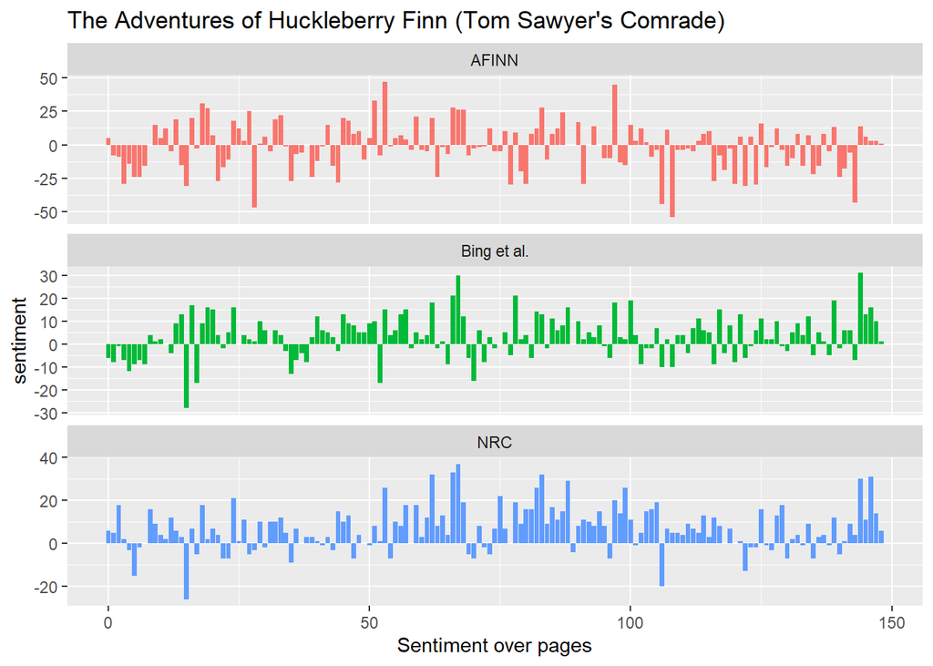

```r
bind_rows(afinn,
          bing_and_nrc) %>%
  ggplot(aes(index, sentiment, fill = method)) +
  geom_col(show.legend = FALSE) +
  facet_wrap(~method, ncol = 1, scales = "free_y")+
  labs(title ="The Adventures of Huckleberry Finn (Tom Sawyer's Comrade)") +
  xlab("Sentiment over pages")
```

```r
#get_sentiments("nrc") %>%
#  filter(sentiment %in% c("positive", "negative")) %>%
#  count(sentiment)

#get_sentiments("bing") %>%
#  count(sentiment)
```

## 2.4 Most common positive and negative words

The code is mostly copied over from the [tidytextmining](https://www.tidytextmining.com/sentiment.html) and the sentiment analyses. Changes have been implemented to analyze some of Mark Twain’s body of works.

```r
bing_word_counts <- tidy_MT_book %>%
  inner_join(get_sentiments("bing")) %>%
  count(word, sentiment, sort = TRUE) %>%
  ungroup()
```

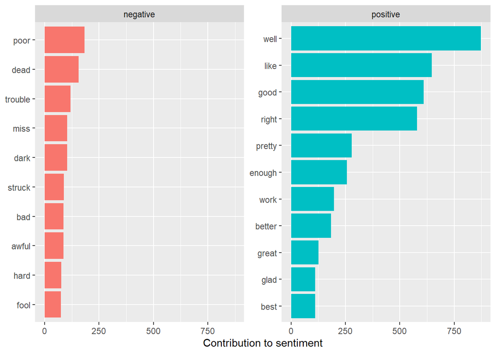

```r
bing_word_counts %>%
  group_by(sentiment) %>%
  slice_max(n, n = 10) %>%
  ungroup() %>%
  mutate(word = reorder(word, n)) %>%
  ggplot(aes(n, word, fill = sentiment)) +
  geom_col(show.legend = FALSE) +
  facet_wrap(~sentiment, scales = "free_y") +
  labs(x = "Contribution to sentiment",
       y = NULL)
```

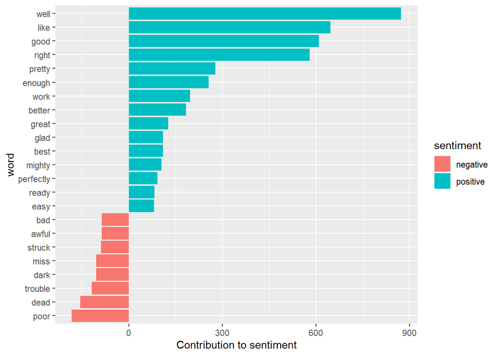

```r
bing_word_counts %>%
  filter(n > 80) %>%
  mutate(n = ifelse(sentiment == "negative", -n, n)) %>%
  mutate(word = reorder(word, n)) %>%
  ggplot(aes(word, n, fill = sentiment)) +
  geom_col() +
  coord_flip() +
  labs(y = "Contribution to sentiment")
```

```r
custom_stop_words <- bind_rows(tibble(word = c("miss"),
                                      lexicon = c("custom")),
                               stop_words)
```

## 2.5 Wordclouds

The code is mostly copied over from the [tidytextmining](https://www.tidytextmining.com/sentiment.html) and the sentiment analyses. Changes have been implemented to analyze some of Mark Twain’s body of works.

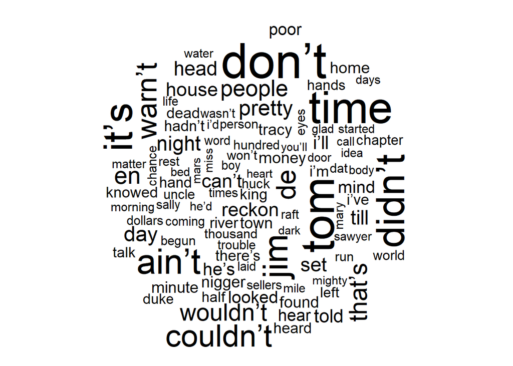

```r
library(wordcloud)

tidy_MT_book %>%
  anti_join(stop_words) %>%
  count(word) %>%
  with(wordcloud(word, n, max.words = 100))
```

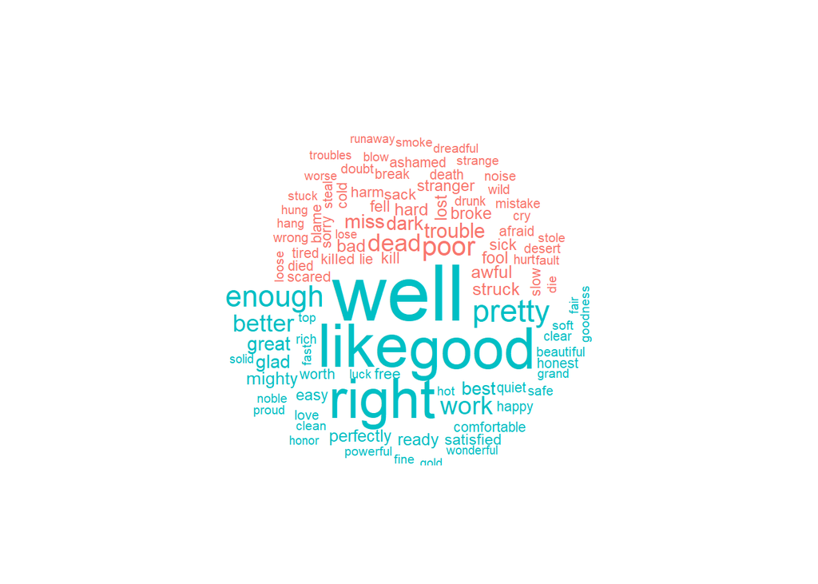

```r
tidy_MT_book %>%
  inner_join(get_sentiments("bing")) %>%
  count(word, sentiment, sort = TRUE) %>%
  acast(word ~ sentiment, value.var = "n", fill = 0) %>%
  comparison.cloud(colors = c("#F8766D", "#00BFC4"),
                   max.words = 100)
```

## 2.6 Looking at units beyond just words

The code is mostly copied over from the [tidytextmining](https://www.tidytextmining.com/sentiment.html) and the sentiment analyses. Changes have been implemented to analyze some of Mark Twain’s body of works.

```r
p_and_p_sentences <- tibble(text = prideprejudice) %>%
  unnest_tokens(sentence, text, token = "sentences")


MT_chapters <- DF_book %>%
  group_by(title) %>%
  unnest_tokens(chapter, text, token = "regex",
                pattern = "Chapter|CHAPTER [\\dIVXLC]") %>%
  ungroup()

MT_chapters %>%
  group_by(title) %>%
  summarise(chapters = n())
```

```
## # A tibble: 6 × 2
##   title                                                     chapters
##   <chr>                                                        <int>
## 1 A Horse's Tale                                                   1
## 2 The Adventures of Huckleberry Finn (Tom Sawyer's Comrade)       44
## 3 The American Claimant                                           51
## 4 The Man That Corrupted Hadleyburg                                1
## 5 Tom Sawyer Abroad                                               27
## 6 Tom Sawyer, Detective                                           23
```

```r
bingnegative <- get_sentiments("bing") %>%
  filter(sentiment == "negative")

wordcounts <- tidy_MT_book %>%
  group_by(title, chapter) %>%
  summarize(words = n())
tidy_MT_book %>%
  semi_join(bingnegative) %>%
  group_by(title, chapter) %>%
  summarize(negativewords = n()) %>%
  left_join(wordcounts, by = c("title", "chapter")) %>%
  mutate(ratio = negativewords/words) %>%
  filter(chapter != 0) %>%
  slice_max(ratio, n = 1) %>%
  ungroup()
```

```
## # A tibble: 4 × 5
##   title                                       chapter negativewords words  ratio
##   <chr>                                         <int>         <int> <int>  <dbl>
## 1 The Adventures of Huckleberry Finn (Tom Sa…      13            76  2057 0.0369
## 2 The American Claimant                            22             3    29 0.103
## 3 Tom Sawyer Abroad                                12             1     5 0.2
## 4 Tom Sawyer, Detective                             5             1     7 0.143
```